# Usando Daa

Juan Bosco Mendoza Vega

20 de agosto de 2018

Mi juego favorito es es Magic: the Gathering. Este es un juego de cartas coleccionable, en el que armas un mazo, siguiendo ciertas limitaciones, con el objetivo de vencer los mazos de tus oponentes.

Este es un hobbie que requiere de una inversión relativamente alta, comparado con otros, así que pensé que sería buena idea hacer un pequeño proyecto de *Data Science* usando R y datos del sitio [MTG Goldfish](http://www.mtggoldfish.com) para estimar la posibilidades de recuperar mi inversión en Magic, en particular, al compara una caja de sobres de cartas.

Y para empezar, una breve introducción a cómo funciona la economía de Magic: the Gathering.

# 1 ¿Cómo funcionan los precios de Magic: the Gathering?

En Magic: the Gathering (Magic), cada año aparecen nuevas cartas a la venta en lo que se denomina *expansiones* o *sets*. Estos *sets* son vendidos en sobres de cartas que contienen, generalmente, 15 cartas al azar. Estos sobres a su vez, pueden ser comprados en cajas que contienen, generalmente, 36 de ellos.

Así que si una persona desea obtener las cartas más recientes de un *set* comprando sobres, depende en gran medida de la suerte.

Como este es un juego y es coleccionable, hay cartas en cada set que son más difíciles de conseguir, pues la frecuencia con la que aparecen al azar en los sobres es menor. Es decir, son cartas más raras.

En Magic las cartas se clasifican por rareza, de las menos a las más raras:

- Común (*Common*)
- Infrecuente (*Uncommon*)
- Rara (*Rara*)
- Mítica (*Mythic*)

Además, Magic: the Gathering tiene un sistema de juego organizado, en el que se organizan distintos eventos competitivos, que van desde torneos en tiendas locales hasta eventos comptitivos nacionales e internacionales.

Lo anterior tiene como consecuencia que aquellas cartas que son efectivas en juego competitivo, pues incrementan las probabilidades de ganar o forman parte de estrategias exitosas, ven un incremento en su costo, pues su demanda se incrementa.

Así, cartas que son raras de conseguir y tienen alta demanda, tienen precios más alto que cartas comunes o poco usadas en juego competitivo. Por supuesto, hay otros factores que inciden en los precios de las cartas, pero para este artículo basta esta explicación simple.

## 1.1 MTG Goldfish

Naturalmente, existen sitios de internet que se encargan de dar seguimiento a los precios de las cartas y sus tendencias. Esta es una información sumamente importante para los jugadores de Magic, pues así conocen el valor de las cartas que poseen y aquellas que desean, para sí tomar decisiones de compra, venta e intercambio.

Uno de estos sitios es [MTG Goldfish](http://www.mtggoldfish.com).

En este sitio se encuentran disponibles información actualizada diariamente de precios de todas las cartas, de todos los *sets* de Magic, presentados en tablas que son muy convenientes para su anáisis usando R.

Además, en este sitio se encuentran excelentes artículos, videos, podcast y artículos a la venta relacionados con Magic. Así que si te gusta Magic o te da curiosidad este juego, no dudes en visitar MTG Goldfish y consumir su contenido, no te arrepentirás… y es una manera de agradecer por la información que generan.

Conociendo todo esto, comencemos el análisis para calcular la probabilidad de recuperar nuestra inversión en una caja de Magic.

# 2 Estructura del análisis.

Las estapas de nuestro análisis son las siguientes

- Descarga de los precios de un *set* desde MTG Goldfish.
- Procesamiento de los precios para facilitar el análisis.
- Análisis exploratorio del *set*.
- Simulación de valores (por sobre de cartas y por caja de sobres).
- Cálculo de probabilidad de recuperar inversión.
- Sistematización del análisis (para ejecutarlo de manera repetida).

Algunos de estás son más complejas o largas que otras, pero si abordamos el análisis dividido por pasos, es más fácil tomar decisiones sobre el anáisis y corregir errores cuando se presentan.

Establecido esto, preparemos nuestro entorno de trabajo.

# 3 Paquetes necesarios

Para este proyecto usaremos los siguientes paquetes:

- **tidyverse**: Una familia de paquetes para importar, manipular, exportar y visualizar datos.
- **rvest**: Funciones para extraer información de páginas web (*scrapping*).
- **xml2**: Este paquete nos permite importar y manipular datos con estructuras xml.
- **scales**: Funciones para mejorar la presentación de datos en gráficos.
- **ggrepel**: Un paquete que expande las funciones de **ggplot2** (parte de *tidyverse*), para mostrar etiquetas sin sobreposiciones entre ellas.

```r
library(tidyverse)
library(rvest)
library(xml2)
library(scales)
library(ggrepel)
```

Como es usual, puedes instalar estos paquetes usando la función `install.packages()`.

Ahora sí, pasemos a la primera etapa del anáisis.

# 4 Descarga de los precios de un *set* desde MTG Goldfish

En MTG Goldfish, la información de los precios de un set de Magic es presentada en su propia pagina, que es identificada usando el código del *set*.

Los *sets* de Magic son identificados por un código de tres caracteres, en mayúsculas. Por ejemplo, para el *set* “Dominaria”, su código es “DOM”, por lo que el URL en el que encontramos sus precios se ecuentran en:

- https://www.mtggoldfish.com/index/DOM

Una lista de los códigos de sets de Magic se encuentra disponible en:

- https://mtg.gamepedia.com/Template:List_of_Magic_sets

Usamos la función `download_html()` del paquete *xml2()* para descargar una página de internet a nuestra carpeta de trabajo. Llamaremos a este archivo “goldfish_DOM.html”.

```r
download_html(url = "https://www.mtggoldfish.com/index/DOM",
              file = "goldfish_DOM.html")
```

Podemos definir una función que nos permita descargar el html que corresponde a un *set* de manera más sencilla, proporcionando el código de tres letras de este.

```r
descargar_set <- function(clave) {
  mtg_url <- paste0("https://www.mtggoldfish.com/index/", clave)
  mtg_archivo <- paste0("goldfish_", clave, ".html")
  download_html(url = mtg_url, file = mtg_archivo)
}
```

Hecho esto, importamos el archivo con el html descargado y lo asignamos al objeto `mtg_dom`.

```r
mtg_dom <- read_html("goldfish_DOM.html")
```

Si llamamos a este objeto, podremos ver que es un documento con estructura de xml.

```r
mtg_dom
```

```
## {xml_document}
## <html xmlns="http://www.w3.org/1999/xhtml">
##  [1] <head>\n<title>Dominaria MTG / MTGO Price History</title>\n<meta na ...
##  [2] <body>\n<img alt="MTGGoldfish" class="layout-print-logo" src="//ass ...
##  [3] <div class="container-fluid layout-container-fluid">\n<div id="erro ...
##  [4] <div class="layout-bottom-ad">\n\n  <div class="ads-container-cdm-z ...
##  [5] <div class="layout-bottom-banner">\n<div class="layout-bottom-conte ...
##  [6] <div class="bottom-shelf">\n<div class="banner-contents">\n<p class ...
##  [7] <div aria-hidden="true" aria-labelledby="Login Dialog" class="modal ...
##  [8] <div aria-hidden="true" aria-labelledby="Important Updates" class=" ...
##  [9] <div aria-hidden="true" aria-labelledby="Card Popup" class="modal f ...
## [10] <div class="layout-typePreferencePopup" id="type-preference-popup"> ...
## [11] <script src="//assets1.mtggoldfish.com/assets/application-fef731ca0 ...
## [12] <script src="//assets1.mtggoldfish.com/assets/google_analytics-b937 ...
## [13] <div id="cdm-zone-end"></div>\n
## [14] <script>\nvar _comscore = _comscore || [];\n_comscore.push({ c1: "2 ...
## [15] <noscript>\n   <img src="//b.scorecardresearch.com/p?c1=2&amp;c2=60 ...
## [16] <script type="text/javascript">\n(function () {\n   var d = new Ima ...
## [17] <noscript>\n   &lt;div&gt;&lt;img src="//secure-us.imrworldwide.com ...
```

Con este formato no podemos hacer mucho. Necesitamos extraer los datos que contiene y para ello, usaremos las funciones del paquete **rvest**.

# 5 Procesamiento de los precios para facilitar el análisis

**rvest** es un paquete usado para extraer y procesar información de documentos html o xml. En nuestro caso, lo haremos a través del uso de identificadores *CSS*.

No nos detendremos a explicar qué son los identificadores *CSS*, pero en términos generales, podemos decir que estos describen los elementos y características de una documento html. Puedes leer más al respecto en el siguiente enlace:

- https://www.w3schools.com/css/

Vamos a recuperar los datos de precios de las cartas, así que necesitamos los identificadores *CSS* de estos datos en particular.

Para obtener los identificadores hay distintos procedimientos. Puedes usar la función “Inspeccionar elemento” de tu navegador de internet y explorar la estructura del documento.

También puedes usar el sitio Selector Gadget para recuperar los identificadores *CSS*:

- https://selectorgadget.com/

Para fines de este artículo, ya he realizado esta tarea. los identificadores *CSS* que nos interesan son: “.index-price-table-paper tbody tr”.

Con esta información, usamos la función `html_node()` de *rvest()*.

```r
mtg_dom %>%
  html_node(css = ".index-price-table-paper tbody tr")
```

```
## {xml_node}
## <tr>
## [1] <td class="card"><a data-full-image="https://cdn1.mtggoldfish.com/im ...
## [2] <td>DOM</td>
## [3] <td>Mythic</td>
## [4] <td class="text-right">\n48.90\n</td>
## [5] <td class="text-right">\n<div class="common-price-change">\n+0.02\n\ ...
## [6] <td class="text-right">0.00%</td>
## [7] <td class="text-right">\n<div class="common-price-change">\n+1.95\n\ ...
## [8] <td class="text-right">+4.00%</td>
```

Aún no es un formato útil para el análisis necesitamos la función `html_text()`. Hacer esto nos devolverá una cantidad considerable de texto, asi que pediremos que se nos muestren sólo las primeras líneas con `head()`.

```r
mtg_dom %>%
  html_nodes(css = ".index-price-table-paper tbody tr") %>%
  html_text() %>%
  head()
```

```
## [1] "Teferi, Hero of Dominaria\nDOM\nMythic\n\n48.90\n\n\n\n+0.02\n\n\n\n\n\n0.00%\n\n\n+1.95\n\n\n\n\n\n+4.00%\n"
## [2] "Karn, Scion of Urza\nDOM\nMythic\n\n31.59\n\n\n\n-0.09\n\n\n\n\n\n0.00%\n\n\n-0.33\n\n\n\n\n\n-1.00%\n"
## [3] "Lyra Dawnbringer\nDOM\nMythic\n\n13.00\n\n\n\n+0.01\n\n\n\n\n\n0.00%\n\n\n+0.06\n\n\n\n\n\n0.00%\n"
## [4] "Mox Amber\nDOM\nMythic\n\n11.46\n\n\n\n-0.02\n\n\n\n\n\n0.00%\n\n\n-0.01\n\n\n\n\n\n0.00%\n"
## [5] "History of Benalia\nDOM\nMythic\n\n10.60\n\n\n\n-0.03\n\n\n\n\n\n0.00%\n\n\n+0.06\n\n\n\n\n\n+1.00%\n"
## [6] "Sulfur Falls\nDOM\nRare\n\n4.64\n\n\n\n+0.05\n\n\n\n\n\n+1.00%\n\n\n+0.13\n\n\n\n\n\n+3.00%\n"
```

El resultado es algo más manejable que el *xml* original, pero requiere más procesamiento.

Usamos la función `str_split()` con `as.data.frame()` de *R base* y `tbl_df()` de *dplyr*, para convertir el resultado anterior a un *data frame*, que llamaremos `df_dom`.

```r
df_dom <-
  mtg_dom %>%
  html_nodes(css = ".index-price-table-paper tbody tr") %>%
  html_text() %>%
  str_split(pattern = "\\n", simplify = T) %>%
  as.data.frame() %>%
  tbl_df()
```

Nuestro resultado es el siguiente.

```r
df_dom
```

```
## # A tibble: 277 x 25
##    V1    V2    V3    V4    V5    V6    V7    V8    V9    V10   V11   V12
##    <fct> <fct> <fct> <fct> <fct> <fct> <fct> <fct> <fct> <fct> <fct> <fct>
##  1 Tefe~ DOM   Myth~ ""    48.90 ""    ""    ""    +0.02 ""    ""    ""
##  2 Karn~ DOM   Myth~ ""    31.59 ""    ""    ""    -0.09 ""    ""    ""
##  3 Lyra~ DOM   Myth~ ""    13.00 ""    ""    ""    +0.01 ""    ""    ""
##  4 Mox ~ DOM   Myth~ ""    11.46 ""    ""    ""    -0.02 ""    ""    ""
##  5 Hist~ DOM   Myth~ ""    10.60 ""    ""    ""    -0.03 ""    ""    ""
##  6 Sulf~ DOM   Rare  ""    4.64  ""    ""    ""    +0.05 ""    ""    ""
##  7 Jaya~ DOM   Myth~ ""    4.49  ""    ""    ""    +0.02 ""    ""    ""
##  8 Gobl~ DOM   Rare  ""    4.23  ""    ""    ""    +0.01 ""    ""    ""
##  9 Stee~ DOM   Rare  ""    3.91  ""    ""    ""    -0.01 ""    ""    ""
## 10 Wood~ DOM   Rare  ""    3.91  ""    ""    ""    +0.05 ""    ""    ""
## # ... with 267 more rows, and 13 more variables: V13 <fct>, V14 <fct>,
## #   V15 <fct>, V16 <fct>, V17 <fct>, V18 <fct>, V19 <fct>, V20 <fct>,
## #   V21 <fct>, V22 <fct>, V23 <fct>, V24 <fct>, V25 <fct>
```

Aun tenemos que pulir un poco nuestro *data frame*, en particular, seleccionando sólo las columnas que nos interesan entre todas las disponibles. Haremos esto con `select()` de **dplyr**

```r
df_dom <-
  df_dom %>%
  select("Carta" = V1, "Set" = V2, "Rareza" = V3, "Precio" = V5) %>%
  mutate(Precio = as.numeric(as.character(Precio)),
         Rareza = factor(Rareza, levels = c("Basic Land","Common",
                                            "Uncommon", "Rare", "Mythic"))) %>%
  mutate_at(c("Carta", "Set"), as.character) %>%
  filter(Rareza != "Basic Land")
```

Nuestro resultado será un *data frame* con cuatro columnas: el nombre de las cartas, el *set*, la rareza, y el precio.

```r
df_dom
```

```
## # A tibble: 257 x 4
##    Carta                     Set   Rareza Precio
##    <chr>                     <chr> <fct>   <dbl>
##  1 Teferi, Hero of Dominaria DOM   Mythic  48.9
##  2 Karn, Scion of Urza       DOM   Mythic  31.6
##  3 Lyra Dawnbringer          DOM   Mythic  13
##  4 Mox Amber                 DOM   Mythic  11.5
##  5 History of Benalia        DOM   Mythic  10.6
##  6 Sulfur Falls              DOM   Rare     4.64
##  7 Jaya Ballard              DOM   Mythic   4.49
##  8 Goblin Chainwhirler       DOM   Rare     4.23
##  9 Steel Leaf Champion       DOM   Rare     3.91
## 10 Woodland Cemetery         DOM   Rare     3.91
## # ... with 247 more rows
```

## 5.1 Definiendo una función para importar y procesar precios

Podemos transformar el proceso anterior en una función, llamada `leer_html()` para así generar fácilmente data frames a partir del html de páginas de **MTG Goldfish**.

```r
leer_html <- function(archivo_html) {
  archivo_html %>%
    read_html() %>%
    html_nodes(css = ".index-price-table-paper tbody tr") %>%
    html_text() %>%
    str_split(pattern = "\\n", simplify = T) %>%
    as.data.frame() %>%
    select("Carta" = V1, "Set" = V2, "Rareza" = V3, "Precio" = V5) %>%
    mutate(Precio = as.numeric(as.character(Precio)),
           Rareza = factor(Rareza,
                           levels = c("Basic Land","Common",
                                      "Uncommon", "Rare", "Mythic"))) %>%
    mutate_at(c("Carta", "Set"), as.character) %>%
    filter(Rareza != "Basic Land") %>%
    tbl_df()
}
```

De este modo, casi hemos terminado el procesamiento de los precios, pero antes tenemos que hacer una recodificación.

## 5.2 Identificando *outliers*

Como deseamos analizar las probabilidades de recuperar nuestra inversión en un set de Magic, nos conviene identificar aquellas cartas que tienen un valor excepcionalente alto, con respecto a las demás. Esta información no permitirá hacer un análisis más fino de los precios con los que contamos.

Por supuesto, estas cartas con precios excepcionales, son *outliers*. En cuanto a *outliers* no hay un concenso en cómo caracterizarlos. Para fines de este proyecto, usaremos como criterio para etiquetar un dato como. *outlier* el usando al generar gráficos de caja y bigote (*boxplot*), que es:

- Un dato menor a: el valor del primer cuartil menos una vez y media el rango intercuartílico.
- Un dato mayor a: el valor del tercer cuartil más una vez y media el rango intercuartílico.

Estos son los datos que se salen de los “bigotes” de un *boxplot* y son mostrados como puntos en estos diagramas.

Sólo etiquetaremos los *outliers* “altos”, pues son los relevantes para el análisis que estamos haciendo.

Definimos entonces una función que implemente el criterio anterior. Al darle un vector numérico, nos será devuelto un vector lógico del mismo largo, donde el valor `TRUE` serán los *outliers* y `FALSE` los demás datos.

```r
tag_outlier <- function(datos) {
  ifelse(datos > quantile(datos, .75) + IQR(datos) * 1.5,
         TRUE, FALSE)
}
```

Aplicamos esta función, agrupando por nuestras cartas por rareza. No tiene mucho sentido comparar los precios de cartas Comunes con Míticas, pues estas últimas *siempre* tienen un precio más alto que las primeras por ser más difíciles de obtener.

Hacemos un `mutate()` adicional para etiquetar los outlier con el nombre de la carta, esto nos será útil más adelante. Podría usar una sola llamada de `mutate()`, pero he preferido presentarlo así para hacer más claro qué está ocurriendo.

```r
df_dom <-
  df_dom %>%
  group_by(Rareza) %>%
  mutate(Outlier = tag_outlier(Precio)) %>%
  mutate(Outlier = ifelse(Outlier, Carta, NA))
```

Nuestro resultado es el siguiente.

```r
df_dom
```

```
## # A tibble: 257 x 5
## # Groups:   Rareza [4]
##    Carta                     Set   Rareza Precio Outlier
##    <chr>                     <chr> <fct>   <dbl> <chr>
##  1 Teferi, Hero of Dominaria DOM   Mythic  48.9  Teferi, Hero of Dominaria
##  2 Karn, Scion of Urza       DOM   Mythic  31.6  Karn, Scion of Urza
##  3 Lyra Dawnbringer          DOM   Mythic  13    <NA>
##  4 Mox Amber                 DOM   Mythic  11.5  <NA>
##  5 History of Benalia        DOM   Mythic  10.6  <NA>
##  6 Sulfur Falls              DOM   Rare     4.64 Sulfur Falls
##  7 Jaya Ballard              DOM   Mythic   4.49 <NA>
##  8 Goblin Chainwhirler       DOM   Rare     4.23 Goblin Chainwhirler
##  9 Steel Leaf Champion       DOM   Rare     3.91 Steel Leaf Champion
## 10 Woodland Cemetery         DOM   Rare     3.91 Woodland Cemetery
## # ... with 247 more rows
```

Por supuesto, podemos definir otra función para llevar a cabo el proceso anterior. Llamaremos a esta función `etiquetar_outlier()`.

```r
etiquetar_outlier <- function(mtg_df) {
  mtg_df %>%
  group_by(Rareza) %>%
  mutate(Outlier = tag_outlier(Precio)) %>%
  mutate(Outlier = ifelse(Outlier, Carta, NA))
}
```

Nuestro siguiente paso es explorar el set “Dominaria”.

# 6 Análisis exploratorio del set

Iniciemos la exploración con los estadísticos descriptivos más elementales: la media, mediana estándar y máximo y mínimo de los precios.

La desviación estándar, aunque es un estadístico descriptivo por excelencia, en este caso es poco informativa debido a la forma en que se distribuyen los precios. En Magic, los precios no tienen una distribución normal o cercana a una normal, pues tienden a exitir muchas cartas con precio bajo y casi idéntico, con algunas pocas cartas con precios muy altos. Por lo tanto, una medida de dispersión como la desviación estándar no nos ayuda mucho a describir lo que nos encontraremos.

Usamos las funciones `group_by()` y `summarize()` de *dplyr*, para aplicar las funciones `mean()`, `median()`, `min()` y `max()`, que corresponden a los estadísiticos ya mencionados, por rareza.

```r
df_dom %>%
  group_by(Rareza) %>%
  summarize(Media = mean(Precio), Mediana = median(Precio),
            Minimo = min(Precio), Maximo = max(Precio))
```

```
## # A tibble: 4 x 5
##   Rareza   Media Mediana Minimo Maximo
##   <fct>    <dbl>   <dbl>  <dbl>  <dbl>
## 1 Common   0.150    0.14   0.12   0.88
## 2 Uncommon 0.309    0.23   0.15   1.75
## 3 Rare     1.03     0.54   0.25   4.64
## 4 Mythic   9.15     2.88   1.12  48.9
```

Confirmamos que las cartas comunes son las menos caras de todas y las míticas las más costosas. También es evidente que hay una variación muy alta entre el precio mínimo y el máximo, en todas las rarezas, particularmente en raras y míticas.

También podemos visualizar cómo se distribuyen los precios creaando un gráfico de densidad con *ggplot2*, llamando la función `geom_density()` de este paquete.

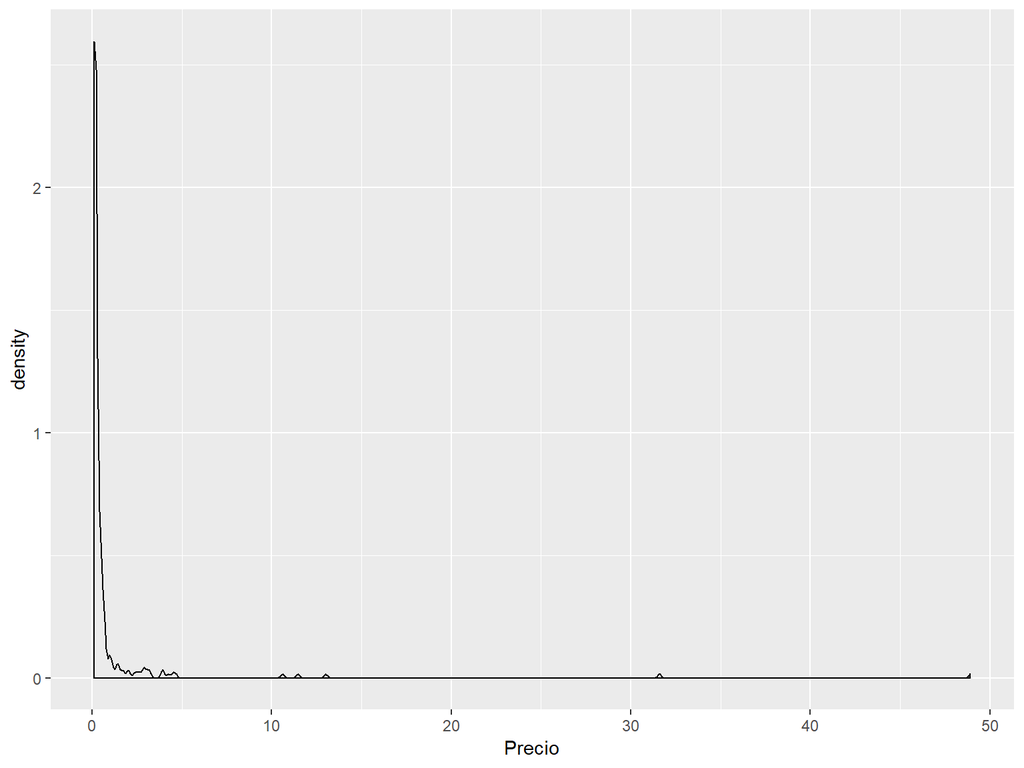

```r
df_dom %>%
  ggplot() +
  aes(Precio) +
  geom_density()
```

Debido a que tenemos diferencias considerables entre los precios más bajos y más altos, esta gráfica no aporta mucha información.

Sin embargo, ya sabemos que los precios de las cartas dependen de su rareza. Las cartas más raras tienden a ser más caras podemos visualizar los precios por rareza puede ser más útil.

Usamos la función `facet_wrap()` de *ggplot2* para generar un gráfico con las características anteriores. Usamos el argumento `scales = "free"` para que los ejes `x` y `y` sean escaladas de manera independiente. En el eje `x` se mostrará el precio y en el `y` la densidad.

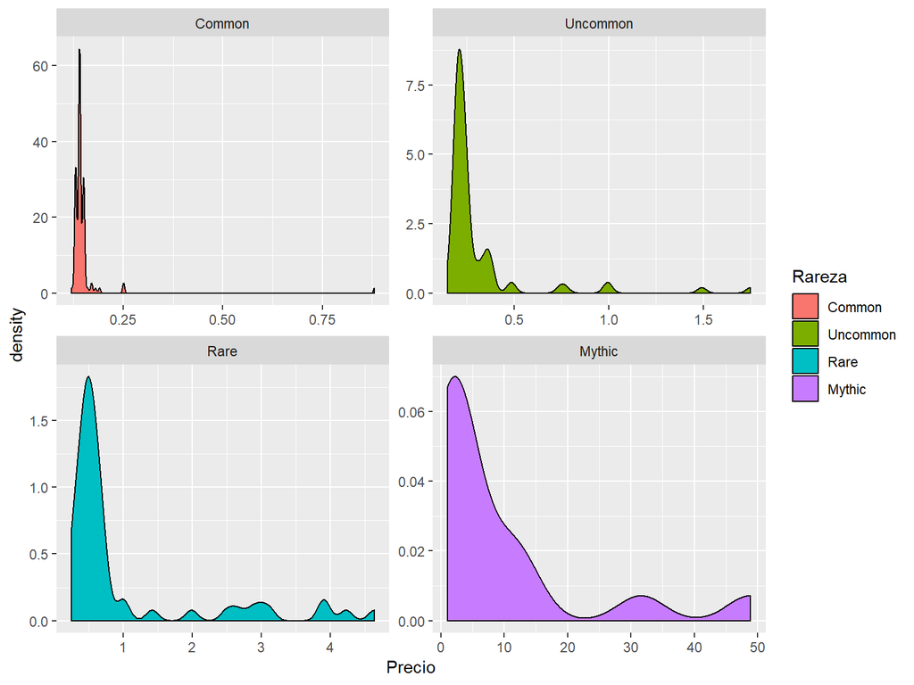

```r
df_dom %>%
  ggplot() +
  aes(Precio, fill = Rareza) +
  geom_density() +
  facet_wrap(~Rareza, scales = "free")
```

De esta manera es más claro observar la distribución de los precios.También confirmamos lo que anticipabamos, los precios no tienen una distribución parecida a una normal.

Finalmente, podemos explorar los precios deeste *set* por rareza usando diagramas de caja y bigotes (*boxplots*). La ventaja de emplear esta forma de visualización es que podemos ver fácilemente las cartas que hemos marcado como *outliers*.

Para lo anterior, usamos la función `geom_boxplot()` de *ggplot2* para generar el diagrama y `geom_label_repel()` de *ggrepel* para agregar etiquetas. Esta última función es una versión de `geom_label()` de *ggplot2*, que tiene ajustes para evitar que las etiquetas se superpongan, mejorando así la legibilidad.

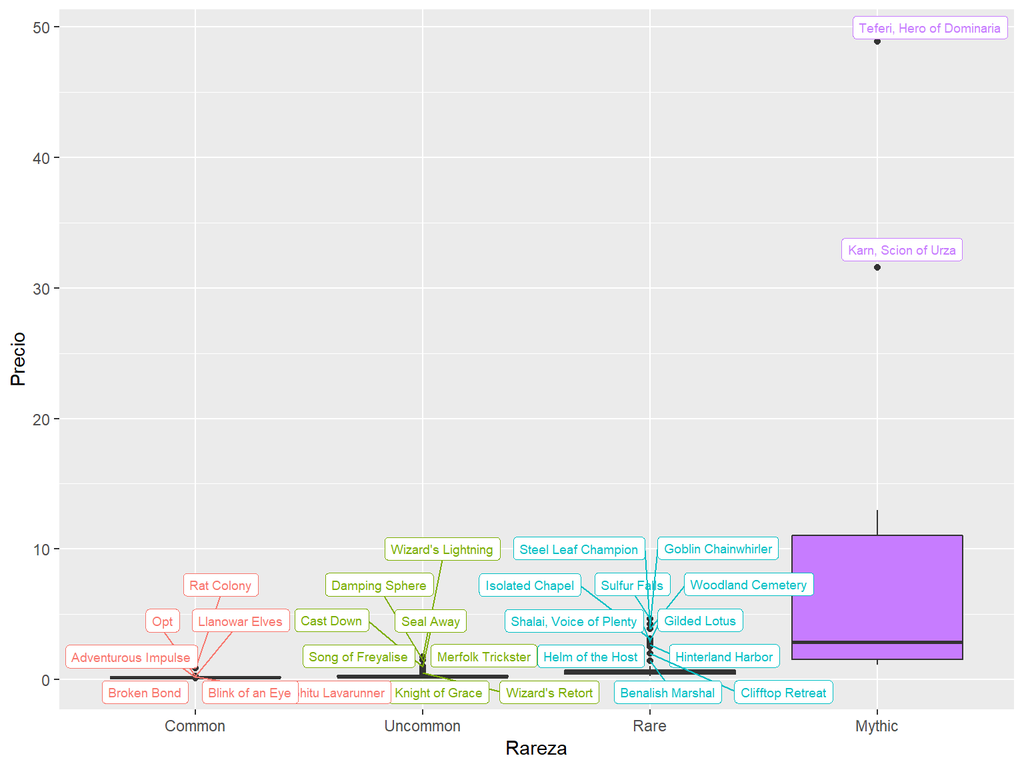

```r
df_dom %>%
  ggplot() +
  aes(Rareza, Precio, fill = Rareza) +
  geom_boxplot() +
  geom_label_repel(aes(label = Outlier, color = Rareza), size = 2.5, fill = "white") +
  theme(legend.position = "none")
```

Creo que con esto tenemos una buena idea general de los precios de “Dominaria”. En particular, podemos identificar aquellas cartas que son especialmente caras, lo cual es una ayuda para comprar, vender e intercambiar.

Aprovechamos para definir una función que realice todas las operaciones de exploración, a la que llamaremos `explorar_set()`. De paso, agregamos unas mejoras de presentación a los gráficos, usando la función `dollar_format()` de *scales*.

```r
explorar_set <- function(mtg_df) {
  exploracion <- list()

  exploracion$precios_resumen <-
    mtg_df %>%
    group_by(Rareza) %>%
    summarize(Media = mean(Precio), Mediana = median(Precio),
              Minimo = min(Precio), Maximo = max(Precio)) %>%
    mutate_if(is.numeric, ~round(., 2))

  exploracion$precios_rareza <-
    mtg_df %>%
    ggplot() +
    aes(Precio, fill = Rareza) +
    geom_density() +
    facet_wrap(~Rareza, scales = "free") +
    scale_x_continuous(labels = dollar_format()) +
    theme_minimal() +
    theme(legend.position = "none")

  exploracion$boxplot <-
    mtg_df %>%
    ggplot() +
    aes(Rareza, Precio, fill = Rareza) +
    geom_boxplot() +
    geom_label_repel(aes(label = Outlier, color = Rareza), size = 2.5, fill = "white") +
    scale_y_continuous(labels = dollar_format()) +
    theme_minimal() +
    theme(legend.position = "none")

  exploracion
}
```

Ahora sí, estamos listos para estimar qué tan probable es que recuperemos nuestra inversión monetaria si decidimos comprar cajas de sobres de una expansión de Magic.

# 7 Simulaciones

Necesitamos definir dos procesos de simulación, una que simule los resultados de abrir un sobre de cartas y una que simula el resultado de abrir unacaja de sobres.

Como mencionamos en la introducción de este proyecto, los *sets* de Magic, normalmente, son vendidos en sobres que contienen 15 cartas, distribuidas de la misma manera:

- 1 carta de tierra básica.
- 10 cartas comunes (Common)
- 3 cartas infrecuentes (Uncommon).
- 1 carta rara (Rare), o 1 carta mítica (Mythic) en uno de cada ocho sobres, aproximadamente.

Estos sobres, a su vez, generalmente se venden en cajas que contienen 36 de ellos

Por lo tanto, necesitamos simular el contenido de un sobre de cartas y repetir ese ejercicio 36 veces, para así determinar el valor monetario de una caja de Magic.

Hecho esto, podremos entonces comparar el valor monetario de una caja de Magic con la inversión que hagamos para comprarla, es decir, el precio que paguemos por ella.

Con estas consideraciones, comencemos simulando sobres.

## 7.1 Simulación de un sobre

Crearemos una lista de listas de pares con las rarezas de las cartas y la frecuencia con la que aparecen, tomando como referencia lo menconado en la sección anterior, de la siguiente manera.

```r
rareza_frecuencia <- list(
  list("Rare", 1),
  list("Uncommon", 3),
  list("Common", 10)
)
```

Cada lista tiene dos elementos, el primero es la Rareza y el segundo es la frecuencia.

Omitimos las cartas de tierra básica, pues estas generalmente no tienen ningún valor financiero.

Usaremos esta lista con una función anómima dentro de la función `map()` de **purrr**. La función `map()` es muy similar a `lapply()` de *R base*, pues aplica una función a todos los elementos de una lista.

Lo que haremos será aplicar una función anónima para filtrar por Rareza las cartas de nuestro *data frame* con los precios de “Dominaria” (primer elemento) y luego extraer una muestra de ellas igual a la frecuencia con la que aparecen (segundo elemento).

Usaremos entonces, en conjunto con `map()`, las funciones `filter()` y `sample_n()` de **dplyr**. Haremos esto con `set.seed()`, para que los resultados sean reprodicibles.

```r
set.seed(2018)

map(rareza_frecuencia, function(pareja){
  df_dom %>%
    filter(Rareza == pareja[[1]]) %>%
    sample_n(size = pareja[[2]])
})
```

```
## [[1]]
## # A tibble: 1 x 5
## # Groups:   Rareza [1]
##   Carta                    Set   Rareza Precio Outlier
##   <chr>                    <chr> <fct>   <dbl> <chr>
## 1 Traxos, Scourge of Kroog DOM   Rare     0.66 <NA>
##
## [[2]]
## # A tibble: 3 x 5
## # Groups:   Rareza [1]
##   Carta               Set   Rareza   Precio Outlier
##   <chr>               <chr> <fct>     <dbl> <chr>
## 1 Memorial to Genius  DOM   Uncommon   0.23 <NA>
## 2 Merfolk Trickster   DOM   Uncommon   0.77 Merfolk Trickster
## 3 Dauntless Bodyguard DOM   Uncommon   0.35 <NA>
##
## [[3]]
## # A tibble: 10 x 5
## # Groups:   Rareza [1]
##    Carta               Set   Rareza Precio Outlier
##    <chr>               <chr> <fct>   <dbl> <chr>
##  1 Arcane Flight       DOM   Common   0.14 <NA>
##  2 Deep Freeze         DOM   Common   0.14 <NA>
##  3 Run Amok            DOM   Common   0.14 <NA>
##  4 Grow from the Ashes DOM   Common   0.15 <NA>
##  5 Tolarian Scholar    DOM   Common   0.13 <NA>
##  6 Soul Salvage        DOM   Common   0.14 <NA>
##  7 Arbor Armament      DOM   Common   0.14 <NA>
##  8 Demonic Vigor       DOM   Common   0.14 <NA>
##  9 Shivan Fire         DOM   Common   0.13 <NA>
## 10 Academy Drake       DOM   Common   0.13 <NA>
```

Como usaremos de manera repetida esta función anónima, es mejor que le demos nombre y la definamos. La llamaremos `pareja()`.

```r
pareja <- function(lista, datos) {
  datos %>%
    filter(Rareza == lista[1]) %>%
    sample_n(size = as.numeric(lista[2]))
}
```

De esta manera, podemos usar `map()` para generar sobres con una sola línea.

```r
set.seed(2018)
map(rareza_frecuencia, pareja, datos = df_dom)
```

```
## [[1]]
## # A tibble: 1 x 5
## # Groups:   Rareza [1]
##   Carta                    Set   Rareza Precio Outlier
##   <chr>                    <chr> <fct>   <dbl> <chr>
## 1 Traxos, Scourge of Kroog DOM   Rare     0.66 <NA>
##
## [[2]]
## # A tibble: 3 x 5
## # Groups:   Rareza [1]
##   Carta               Set   Rareza   Precio Outlier
##   <chr>               <chr> <fct>     <dbl> <chr>
## 1 Memorial to Genius  DOM   Uncommon   0.23 <NA>
## 2 Merfolk Trickster   DOM   Uncommon   0.77 Merfolk Trickster
## 3 Dauntless Bodyguard DOM   Uncommon   0.35 <NA>
##
## [[3]]
## # A tibble: 10 x 5
## # Groups:   Rareza [1]
##    Carta               Set   Rareza Precio Outlier
##    <chr>               <chr> <fct>   <dbl> <chr>
##  1 Arcane Flight       DOM   Common   0.14 <NA>
##  2 Deep Freeze         DOM   Common   0.14 <NA>
##  3 Run Amok            DOM   Common   0.14 <NA>
##  4 Grow from the Ashes DOM   Common   0.15 <NA>
##  5 Tolarian Scholar    DOM   Common   0.13 <NA>
##  6 Soul Salvage        DOM   Common   0.14 <NA>
##  7 Arbor Armament      DOM   Common   0.14 <NA>
##  8 Demonic Vigor       DOM   Common   0.14 <NA>
##  9 Shivan Fire         DOM   Common   0.13 <NA>
## 10 Academy Drake       DOM   Common   0.13 <NA>
```

Como necesitamos un *data frame* para análisis posteriores, corremos lo anterior seguido de la función `reduce()` de *purrr*, que aplica una función de manera secuencial a todos los elementos de una lista, por parejas.

Aplicaremos `bind_rows()` de *dplyr* para obtener como resultado un data frame.

```r
set.seed(8102)
map(rareza_frecuencia, pareja, datos = df_dom) %>%
  reduce(bind_rows)
```

```
## # A tibble: 14 x 5
## # Groups:   Rareza [3]
##    Carta               Set   Rareza   Precio Outlier
##    <chr>               <chr> <fct>     <dbl> <chr>
##  1 Squee, the Immortal DOM   Rare       0.62 <NA>
##  2 Thallid Soothsayer  DOM   Uncommon   0.2  <NA>
##  3 Urza's Tome         DOM   Uncommon   0.19 <NA>
##  4 Orcish Vandal       DOM   Uncommon   0.19 <NA>
##  5 Saproling Migration DOM   Common     0.15 <NA>
##  6 Cloudreader Sphinx  DOM   Common     0.13 <NA>
##  7 Academy Journeymage DOM   Common     0.15 <NA>
##  8 Opt                 DOM   Common     0.25 Opt
##  9 Rampaging Cyclops   DOM   Common     0.13 <NA>
## 10 Fiery Intervention  DOM   Common     0.12 <NA>
## 11 Relic Runner        DOM   Common     0.13 <NA>
## 12 Sergeant-at-Arms    DOM   Common     0.15 <NA>
## 13 Charge              DOM   Common     0.14 <NA>
## 14 Primordial Wurm     DOM   Common     0.13 <NA>
```

Lo anterior, aunque cumple nuetro cometido, no nos permite crear sobres con cartas míticas. Necesitamos solucionar esta situación.

## 7.2 Las cartas míticas

Dado que las cartas míticas aparecen en un sobre una de cada ocho veces ($p = \frac{1}{8}$), podemos simular este comportamiento con una distribución binomial.

Usamos la función `rbinom()`, para generar 1 y 0 al azar, teniendo el 1 una probabilidad de $\frac{1}{8}$ de ocurrir, esto es, 12.5% de los casos.

Pongamos esto a prueba, simulando 40 números con estas probabilidades.

```r
rbinom(n = 40, size = 1, prob = 1/8)
```

```
##  [1] 0 0 1 0 0 0 1 1 0 1 0 0 0 0 0 0 0 0 0 0 0 0 0 1 0 0 0 0 0 0 0 1 0 0 0
## [36] 0 0 0 0 0
```

Luce bien.

Lo que haremos será establecer una condición con `ìf`. Si la rareza de la que estamos extrayendo cartas es “Rare” y al mismo tiempo obtenemos un 1 de simular una distribución binomial con las características descritas arriba.

Dado lo anterior, lo siguiente nos devolverá una carta Rara.

```r
set.seed(6)
rareza_frecuencia %>%
  map(function(x) {
    if(x[[1]] == "Rare" & rbinom(n = 1, size = 1, prob = 1/8)) {
      "Mythic"
    } else {
      x[[1]]
    }
  })
```

```
## [[1]]
## [1] "Rare"
##
## [[2]]
## [1] "Uncommon"
##
## [[3]]
## [1] "Common"
```

Y lo siguiente una carta Mítica.

```r
set.seed(7)
rareza_frecuencia %>%
  map(function(x) {
    if(x[[1]] == "Rare" & rbinom(n = 1, size = 1, prob = 1/8)) {
      "Mythic"
    } else {
      x[[1]]
    }
  })
```

```
## [[1]]
## [1] "Mythic"
##
## [[2]]
## [1] "Uncommon"
##
## [[3]]
## [1] "Common"
```

Combinamos esto con la función `pareja()` para definir una función llamada `simular_sobre()`.

```r
simular_sobre <- function(tabla) {
  rareza_frecuencia <- list(
    c("Rare", 1),
    c("Uncommon", 3),
    c("Common", 10)
  )

  rareza_frecuencia <-
    map(rareza_frecuencia, function(x) {
      if(x[[1]] == "Rare" & rbinom(n = 1, size = 1, prob = 1/8)) {
        x[[1]] <- "Mythic"
      } else {
        x[[1]]
      }
      x
    })

  map(rareza_frecuencia, pareja, datos = tabla) %>%
    reduce(bind_rows)
}
```

Pongamos a prueba nuestra función `simular_sobre()`.

```r
set.seed(7)
simular_sobre(tabla = df_dom)
```

```
## # A tibble: 14 x 5
## # Groups:   Rareza [3]
##    Carta                 Set   Rareza   Precio Outlier
##    <chr>                 <chr> <fct>     <dbl> <chr>
##  1 Karn, Scion of Urza   DOM   Mythic    31.6  Karn, Scion of Urza
##  2 Fight with Fire       DOM   Uncommon   0.3  <NA>
##  3 Memorial to War       DOM   Uncommon   0.2  <NA>
##  4 Settle the Score      DOM   Uncommon   0.25 <NA>
##  5 Benalish Honor Guard  DOM   Common     0.13 <NA>
##  6 Meandering River      DOM   Common     0.15 <NA>
##  7 Jousting Lance        DOM   Common     0.14 <NA>
##  8 Blessed Light         DOM   Common     0.13 <NA>
##  9 Voltaic Servant       DOM   Common     0.15 <NA>
## 10 Dub                   DOM   Common     0.14 <NA>
## 11 Llanowar Scout        DOM   Common     0.15 <NA>
## 12 Knight of New Benalia DOM   Common     0.14 <NA>
## 13 Corrosive Ooze        DOM   Common     0.15 <NA>
## 14 Feral Abomination     DOM   Common     0.14 <NA>
```

Equipados con esta función, podremos crear cajas de sobres fácilmente.

## 7.3 Simular caja de sobres

Una vez más, usamos la función `map()`, aplicando la función `simular_sobre()` 36 veces.

```r
set.seed(8244)
caja_dom <- map(1:36, ~simular_sobre(tabla = df_dom))
```

De esta manera obtenemos una lista con 36 elementos, cada uno de ellos representando un sobre de Magic. Por ejemplo, este es el cuarto “sobre” de la lista anterior.

```r
caja_dom[[4]]
```

```
## # A tibble: 14 x 5
## # Groups:   Rareza [3]
##    Carta                       Set   Rareza   Precio Outlier
##    <chr>                       <chr> <fct>     <dbl> <chr>
##  1 Primevals' Glorious Rebirth DOM   Rare       0.39 <NA>
##  2 Goblin Barrage              DOM   Uncommon   0.21 <NA>
##  3 Shield of the Realm         DOM   Uncommon   0.2  <NA>
##  4 Final Parting               DOM   Uncommon   0.25 <NA>
##  5 Soul Salvage                DOM   Common     0.14 <NA>
##  6 Rescue                      DOM   Common     0.13 <NA>
##  7 Call the Cavalry            DOM   Common     0.14 <NA>
##  8 Befuddle                    DOM   Common     0.13 <NA>
##  9 Invoke the Divine           DOM   Common     0.14 <NA>
## 10 Mesa Unicorn                DOM   Common     0.14 <NA>
## 11 Adventurous Impulse         DOM   Common     0.18 Adventurous Impulse
## 12 Cold-Water Snapper          DOM   Common     0.14 <NA>
## 13 Academy Drake               DOM   Common     0.13 <NA>
## 14 Artificer's Assistant       DOM   Common     0.15 <NA>
```

Definamos entonces una función para simular una caja de Magic, que nos de como resultado un data frame con los 36 sobres, utilizando `reduce()` y `bind_rows()`.

```r
simular_caja <- function(datos) {
  map(1:36, ~simular_sobre(tabla = df_dom)) %>%
    reduce(bind_rows)
}
```

Probamos nuestra función y asignemos el resultado al objeto `caja_dom`.

```r
set.seed(8244)
caja_dom <- simular_caja(datos = df_fom)
```

Comprobamos que hemos generado 36 cartas Raras o Míticas.

```r
caja_dom %>%
  filter(Rareza %in% c("Rare", "Mythic"))
```

```
## # A tibble: 36 x 5
## # Groups:   Rareza [2]
##    Carta                       Set   Rareza Precio Outlier
##    <chr>                       <chr> <fct>   <dbl> <chr>
##  1 Oath of Teferi              DOM   Rare     0.59 <NA>
##  2 Jaya's Immolating Inferno   DOM   Rare     0.46 <NA>
##  3 Naban, Dean of Iteration    DOM   Rare     0.59 <NA>
##  4 Primevals' Glorious Rebirth DOM   Rare     0.39 <NA>
##  5 Shalai, Voice of Plenty     DOM   Rare     2.86 Shalai, Voice of Plenty
##  6 Squee, the Immortal         DOM   Rare     0.62 <NA>
##  7 The Mending of Dominaria    DOM   Rare     0.49 <NA>
##  8 Cabal Stronghold            DOM   Rare     1    <NA>
##  9 Karn, Scion of Urza         DOM   Mythic  31.6  Karn, Scion of Urza
## 10 Primevals' Glorious Rebirth DOM   Rare     0.39 <NA>
## # ... with 26 more rows
```

Para una simulación apropiada, necesitamos repetir generar muchas cajas de sobres.

## 7.4 Simulación de múltiples cajas

Usamos `map()` para repetir 100 veces la función `simular_caja()` y así obtenr esa misma cantidad de cajas. Una vez más, empleamos `reduce()` para obtener como resultado un data frame.

```r
set.seed(3356)

ciencajas_dom <-
  map(1:100, function(x) {
    simular_caja(datos = df_dom) %>%
      summarize(Valor = sum(Precio))
  }) %>%
  reduce(bind_rows)
```

Como anteriormente dejamos agrupados nuestros datos por Rareza, obtendremos un data frame con cerca de 400 renglones, uno por rareza de cada caja de Magic simulada. No siempre serán 400 renglones, pues hay una probabilidad pequeña de que alguna desafortunada caja no tenga ni una sola carta Mítica y con ello su valor se reduzca.

```r
ciencajas_dom
```

```
## # A tibble: 398 x 2
##    Rareza   Valor
##    <fct>    <dbl>
##  1 Common    52.0
##  2 Uncommon  34.0
##  3 Rare      28.3
##  4 Mythic    46
##  5 Common    53.8
##  6 Uncommon  33.0
##  7 Rare      28.0
##  8 Mythic    85.0
##  9 Common    51.9
## 10 Uncommon  35.1
## # ... with 388 more rows
```

Ahora podemos calcular el valor promedio de una caja de “Dominaria” y de las cartas por rareza.

## 7.5 Valor promedio de una caja y por Rareza

Si los deseamos,podemos obtener fácilmente el valor promedio por rareza de las cartas simuladas usando `summarize()` de *dplyr*.

```r
ciencajas_dom %>%
  group_by(Rareza) %>%
  summarize(Promedio = mean(Valor))
```

```
## # A tibble: 4 x 2
##   Rareza   Promedio
##   <fct>       <dbl>
## 1 Common       53.5
## 2 Uncommon     32.2
## 3 Rare         31.2
## 4 Mythic       41.4
```

Sin embargo, necesitamos hacer un pequeño ajuste si buscamos conocer el valor promedio de cada caja de sobres simulada. Necesitamos proporcionar un identificador por caja, para así poder obtener un valor total por cada una de ellas y, con este, calcular el valor promedio por caja.

Hagamos este ajuste y de una vez definamos una función llamada `simular_ciencajas()`, aunque en realidad, podremos definir el número de iteraciones que deseemos, no sólo 100.

```r
simular_ciencajas <- function(datos, iteraciones = 100) {
  map(1:iteraciones, function(num_caja) {
    simular_caja(datos = datos) %>%
      summarize(Valor = sum(Precio)) %>%
      mutate(Id_caja = num_caja)
  }) %>%
  reduce(bind_rows)
}
```

Pongamos a prueba nuestra función.

```r
set.seed(3356)

ciencajas_dom <- simular_ciencajas(datos = df_dom)
```

Nuestro resultado es muy similar al anterior, sólo que ahora tenemos identificador por caja.

```r
ciencajas_dom
```

```
## # A tibble: 398 x 3
##    Rareza   Valor Id_caja
##    <fct>    <dbl>   <int>
##  1 Common    52.0       1
##  2 Uncommon  34.0       1
##  3 Rare      28.3       1
##  4 Mythic    46         1
##  5 Common    53.8       2
##  6 Uncommon  33.0       2
##  7 Rare      28.0       2
##  8 Mythic    85.0       2
##  9 Common    51.9       3
## 10 Uncommon  35.1       3
## # ... with 388 more rows
```

Con este identificador podemos obtener el valor promedio de una caja de sobres de “Dominaria”.

```r
ciencajas_dom %>%
  group_by(Id_caja) %>%
  summarize(Suma = sum(Valor)) %>%
  summarize(Media = mean(Suma))
```

```
## # A tibble: 1 x 1
##   Media
##   <dbl>
## 1  157.
```

La cosa marcha bien, pero podemos hacer nuestro análisis más fino si consideramos una característica del valor de una caja de Magic: las cartas comunes generalmente tiene poca “liquidez”.

Aunque las cartas comunes tienen un valor monetario, a menos que sea una carta de alta demanda y por tanto de un precio particularmente alto, es un poco difícil venderlas y recuperar lo invertido en obtenerlas.

Por suerte nosotros ya hemos etiquetado las cartas comunes con precios inusualmente altos con nuestra función `tag_outlier()`. De este modo, sólo incluiremos a estas al calcular el valor promedio de una caja.

Agregamos esta información en la definición de la función `simular_ciencajas()`.

```r
simular_ciencajas <- function(datos, iteraciones = 100) {
  map(1:iteraciones, function(num_caja) {
    simular_caja(datos = datos) %>%
      filter(Rareza != "Common" | (Rareza == "Common" & !is.na(Outlier)) ) %>%
      summarize(Valor = sum(Precio)) %>%
      mutate(Id_caja = num_caja)
  }) %>%
  reduce(bind_rows)
}
```

Con esta nueva versión de nuestra función `simular_ciencajas()`, simulamos cien cajas de “Dominaria” y, con esos datos, obtenemos su valor promedio. De una vez calculemos también la mediana, el valor que tiene 50% de los precios debajo de él y 50% por encima.

```r
set.seed(3356)
ciencajas_dom <- simular_ciencajas(datos = df_dom)

ciencajas_dom
```

```
## # A tibble: 398 x 3
##    Rareza   Valor Id_caja
##    <fct>    <dbl>   <int>
##  1 Common    5.54       1
##  2 Uncommon 35.7        1
##  3 Rare     29.1        1
##  4 Mythic   50.3        1
##  5 Common    6.55       2
##  6 Uncommon 34.4        2
##  7 Rare     28.6        2
##  8 Mythic   88.4        2
##  9 Common    4.69       3
## 10 Uncommon 36.5        3
## # ... with 388 more rows
```

```r
ciencajas_dom %>%
  group_by(Id_caja) %>%
  summarize(Suma = sum(Valor)) %>%
  summarize(Media = mean(Suma), Mediana = median(Suma))
```

```
## # A tibble: 1 x 2
##   Media Mediana
##   <dbl>   <dbl>
## 1  114.    105.
```

Nuestro promedio, naturalmente, es menor que el obtuvimos antes de excluir las cartas comunes.

Con lo que hemos hecho hasta ahora, podríamos decir cuál es el valor promedio que esperaríamos obtener de una caja de sobres de “Dominaria”. Con ello podemos hacernos una idea general sobre la posibilidad de recuperar nuestra inversión. Si compramos una caja de “Dominaria” por un precio inferior al valor promedio esperado de ellas, deberíamos recuperar nuestra inversión ¿cierto?

Bueno, la cosa no es tan sencila. Calculemos, por fin, la probabilidad de recuperar nuestra inversión.

# 8 Probabilidad de recuperar inversión

Después de simular el valor de múltiples cajas de sobres de Magic, podemos calcular la probabilidad de recuperar lo que hemos invertido en una de ellas a partir de una función de densidad.

Primero, obtenemos el valor de cada caja, agrupando los Precios de las cartas en ellas por **Id_caja**. Una vez que hemos obtenido estos valores, los extraemos como un vector utilizando con la función `pull()` de *dplyr*.

```r
valorcajas_dom <-
  ciencajas_dom %>%
  group_by(Id_caja) %>%
  summarize(Suma = sum(Valor)) %>%
  pull(Suma)
```

Este es nuestro resultado.

```r
valorcajas_dom
```

```
##   [1] 120.59 157.92 137.59 129.49 144.68  92.08  82.55  81.02  82.68  94.98
##  [11] 116.84  81.37 147.84  89.37 125.85 156.98  96.73 142.23  82.71 144.28
##  [21] 136.82 168.66 123.42  74.59  76.03  79.59  84.69 153.15  93.61 117.14
##  [31] 114.65  80.57 145.46 109.91  98.38 100.39 160.42  96.07  88.20 140.94
##  [41] 156.52  87.99  76.05 149.94 104.88  87.42 178.25  81.03 116.11 123.20
##  [51]  91.95 131.84 138.21 115.72  86.93 226.66  86.10 105.74  75.46 144.10
##  [61] 103.94 102.29 120.68  87.68 116.46  84.35 129.69 100.55 162.44  86.80
##  [71] 107.98 153.01  94.81 122.24 184.27 103.72  94.48 103.94 134.81 140.89
##  [81] 142.06  70.47  96.44  74.02  71.87  94.05  87.93 162.85  91.45  87.96
##  [91] 111.11 150.81 139.06  81.86  77.48 198.92  81.58 136.19 126.23  81.47
```

Definimos una función que realice lo anterior, llamada `valor_cajas`.

```r
valor_cajas <- function(cajas_simuladas) {
  cajas_simuladas %>%
    group_by(Id_caja) %>%
    summarize(Suma = sum(Valor)) %>%
    pull(Suma)
}
```

Usamos `density()` en nuestro vector anterior para obtener la función de densidad de estos valores.

```r
densidad_dom <- density(valorcajas_dom)
```

Obtenemos lo siguiente.

```r
densidad_dom
```

```
##
## Call:
##  density.default(x = valorcajas_dom)
##
## Data: valorcajas_dom (100 obs.); Bandwidth 'bw' = 11.45
##
##        x                y
##  Min.   : 36.11   Min.   :3.916e-06
##  1st Qu.: 92.34   1st Qu.:3.641e-04
##  Median :148.56   Median :2.343e-03
##  Mean   :148.56   Mean   :4.442e-03
##  3rd Qu.:204.79   3rd Qu.:8.172e-03
##  Max.   :261.02   Max.   :1.379e-02
```

Si deseamos obtener una gráfica de esta función, usamos `ggplot()` y `geom_area()` de *ggplot2*. Pero antes necesitamos extraer la información de los ejes `x` y `y`, para después convertirla a un *data frame* con `tbl_df()`.

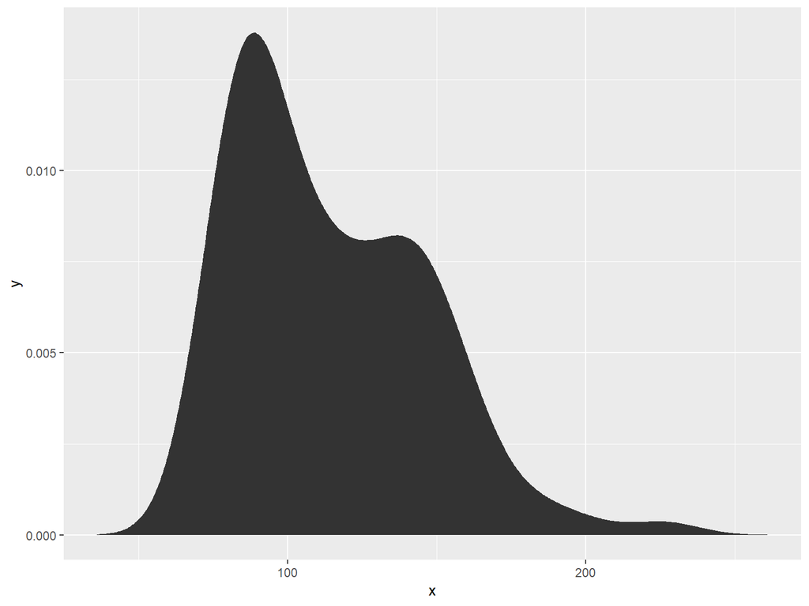

```r
densidad_dom[c("x", "y")] %>%
  tbl_df() %>%
  ggplot() +
  aes(x, y) +
  geom_area()
```

Con esto obtenemos un curva de función y su respectiva área debajo de ella. Esta área representa, aproximadamente, una distribución de todos los valores que podrían tomar las cajas de sobres Magic, a partir de la simulación que hemos realizado. Es decir, el 100% de nuestros casos.

Veamos como luce lo anterior con un valor de 105, que obtuvimos antes.

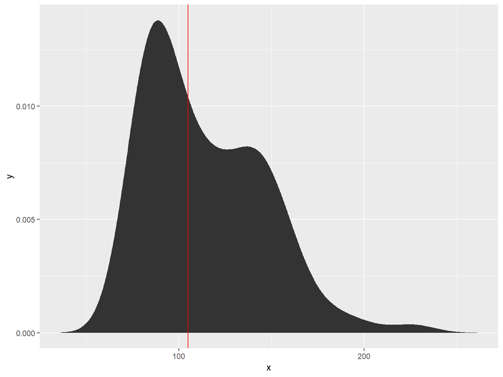

```r
densidad_dom[c("x", "y")] %>%
  tbl_df() %>%
  ggplot() +
  aes(x, y) +
  geom_area() +
  geom_vline(xintercept = 105, color = "red")
```

¡Interesante!

Por lo tanto, si queremos calcular la probabilidad de que recuperemos nuestra inversión al comprar una caja de sobres de Magic, debemos calcular el área que resulta de segmentar nuestra distribución en dos.

Para calcular el área de un segmento bajo la curva, usamos las funciones `approxfun()` e `integrate()`.

Como su nombre lo indica, la función `integrate()` usará integración para calcular un área, por lo que nos pedirá un límite inferior y uno superior.

Supongamos que que hemos comprado una caja de sobres de “Dominaria” en **100 dólares**. Usaremos este valor como límite inferior y el valor máximo de nuestra distribución como límite superior.

```r
densidad_dom %>%
  approxfun() %>%
  integrate(upper = max(valorcajas_dom), lower = 100)
```

```
## 0.5829855 with absolute error < 2.6e-05
```

¡Perfecto!

Lo que hemos obtenido es la probabilidad de que recuperemos nuestra inversión, esto es decir, hay 58% de probabilidad de comprar una caja y que esta tenga un valor mayor que 100 USD.

En este caso es más o menos lanzar una moneda al aire recuperar nuestra inversión si pagamos 100 USD por una caja de “Dominaria”.

Transformemos el proceso anterior a funciones, para repetirlo fácilmente.

# 9 Sistematización del análisis

Primero, definimos una función que calcule la función de densidad, la probabilidad a partir de un costo que elijamos, y el data frame de la función de densidad.

Además, aprovecharemos para etiquetar los valor en el data frame de la función de densidad como menores o mayores al costo elegido.

```r
magic_densidad <- function(valor_cajas, costo_pagado) {
  magic <- list()

  magic$costo_pagado <- costo_pagado

  magic$densidad <-
    density(valor_cajas)

  magic$probabilidad <-
    magic$densidad %>%
    approxfun() %>%
    integrate(upper = max(valor_cajas), lower = costo_pagado)

  magic$df_densidad <-
    magic$densidad[c("x", "y")] %>%
    tbl_df() %>%
    mutate(Tipo = ifelse(x < costo_pagado, "Menor", "Mayor"))

  magic
}
```

El resultado será una lista con cuatro elementos: el costo pagado, la función de densidad, probabilidad y un data frame.

```r
magic_densidad(valorcajas_dom, costo_pagado = 100)
```

```
## $costo_pagado
## [1] 100
##
## $densidad
##
## Call:
##  density.default(x = valor_cajas)
##
## Data: valor_cajas (100 obs.);    Bandwidth 'bw' = 11.45
##
##        x                y
##  Min.   : 36.11   Min.   :3.916e-06
##  1st Qu.: 92.34   1st Qu.:3.641e-04
##  Median :148.56   Median :2.343e-03
##  Mean   :148.56   Mean   :4.442e-03
##  3rd Qu.:204.79   3rd Qu.:8.172e-03
##  Max.   :261.02   Max.   :1.379e-02
##
## $probabilidad
## 0.5829855 with absolute error < 2.6e-05
##
## $df_densidad
## # A tibble: 512 x 3
##        x         y Tipo
##    <dbl>     <dbl> <chr>
##  1  36.1 0.0000143 Menor
##  2  36.5 0.0000163 Menor
##  3  37.0 0.0000185 Menor
##  4  37.4 0.0000209 Menor
##  5  37.9 0.0000236 Menor
##  6  38.3 0.0000267 Menor
##  7  38.7 0.0000301 Menor
##  8  39.2 0.0000338 Menor
##  9  39.6 0.0000381 Menor
## 10  40.1 0.0000428 Menor
## # ... with 502 more rows
```

Ahora, creamos una función que use esta lista para generar un gráfico.

```r
plot_densidad <- function(lista_densidad) {
  label_costo <-
    paste0("Costo pagado: ", lista_densidad$costo_pagado, " USD")

  label_prob <-
    paste0("Probabilidad de recuperar inversión: ",
           round(lista_densidad$probabilidad$value, 4) * 100,
           "%")

  lista_densidad$df_densidad %>%
    ggplot() +
    aes(x, y, fill = Tipo) +
    geom_area() +
    labs(title =  paste0(label_costo, "\n", label_prob)) +
    scale_y_continuous(expand = c(0, 0)) +
    scale_x_continuous(labels = dollar_format()) +
    labs(x = "USD", y = "Densidad") +
    theme_minimal() +
    theme(legend.position = "top")
}
```

Hecho esto, podemos probar con otros costos de una caja de Dominaria. Por ejemplo, si pagamos 90 USD, naturalmente nos irá mejor.

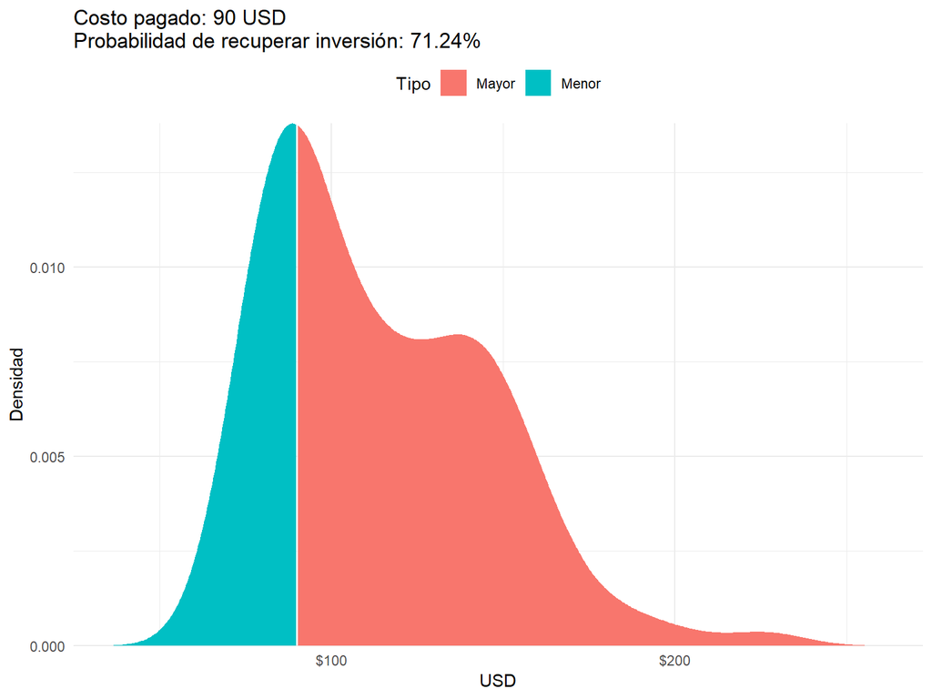

```r
 magic_densidad(valorcajas_dom, 90) %>%
   plot_densidad()
```

Vamos a integrar todos los pasos de nuestro análisis anterior en una sola función llamadad `analisis_set()`.

```r
analisis_set <- function(set_html, costo_pagado = 100) {
  analisis <- list()

  analisis$df <- leer_html(set_html) %>% etiquetar_outlier()

  analisis$explorar <- explorar_set(analisis$df)

  analisis$simulacion <- simular_ciencajas(analisis$df)

  analisis$valor <- valor_cajas(analisis$simulacion)

  analisis$densidad <- magic_densidad(analisis$valor, costo_pagado = costo_pagado)

  analisis$inversion <- plot_densidad(analisis$densidad)

  analisis
}
```

De esta manera, podemos realizar el análisis de cualquier set en un solo paso, siempre y cuando descarguemos primero los datos de este de *MTG Goldfish*. El resultado será una lista con el data frame con los precios del *set*, el análisis exploratorio, incluidas gráficas, el resultado de las simulaciones, y el análisis de la probabilidad de recuperar información.

```r
descargar_set(clave = "XLN")
```

Con los datos de “Ixalan”, podemos realizar una simulación usando nuestra función `analisis_set()` que nos permitirá calcular la probabilidad de recuperar nuestra inversión si compramos cajas de este *set* por 90 USD cada una.

```r
set.seed(25)
ixalan_lista <- analisis_set("goldfish_XLN.html", costo_pagado = 90)
```

Veamos nuestros resultados.

```r
ixalan_lista
```

```
## $df
## # A tibble: 267 x 5
## # Groups:   Rareza [4]
##    Carta                    Set   Rareza Precio Outlier
##    <chr>                    <chr> <fct>   <dbl> <chr>
##  1 Search for Azcanta       XLN   Rare    20.9  Search for Azcanta
##  2 Carnage Tyrant           XLN   Mythic  18.8  Carnage Tyrant
##  3 Vraska's Contempt        XLN   Rare    14.6  Vraska's Contempt
##  4 Vraska, Relic Seeker     XLN   Mythic   8.77 Vraska, Relic Seeker
##  5 Settle the Wreckage      XLN   Rare     7.38 Settle the Wreckage
##  6 Growing Rites of Itlimoc XLN   Rare     6    Growing Rites of Itlimoc
##  7 Glacial Fortress         XLN   Rare     4.99 <NA>
##  8 Drowned Catacomb         XLN   Rare     4.93 <NA>
##  9 Treasure Map             XLN   Rare     4.24 <NA>
## 10 Sunpetal Grove           XLN   Rare     4    <NA>
## # ... with 257 more rows
##
## $explorar
## $explorar$precios_resumen
## # A tibble: 4 x 5
##   Rareza   Media Mediana Minimo Maximo
##   <fct>    <dbl>   <dbl>  <dbl>  <dbl>
## 1 Common    0.15    0.14   0.12   0.31
## 2 Uncommon  0.37    0.22   0.19   3.5
## 3 Rare      2.03    0.75   0.32  20.9
## 4 Mythic    3.41    1.75   0.72  18.8
##
## $explorar$precios_rareza
```

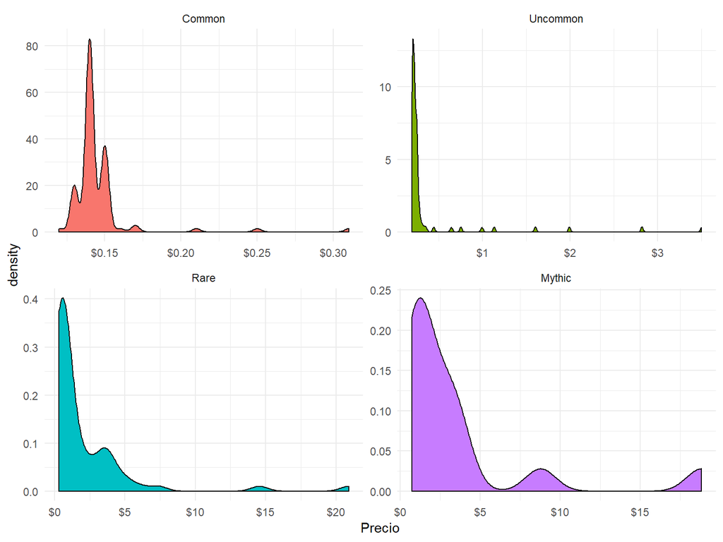

```
##
## $explorar$boxplot
```

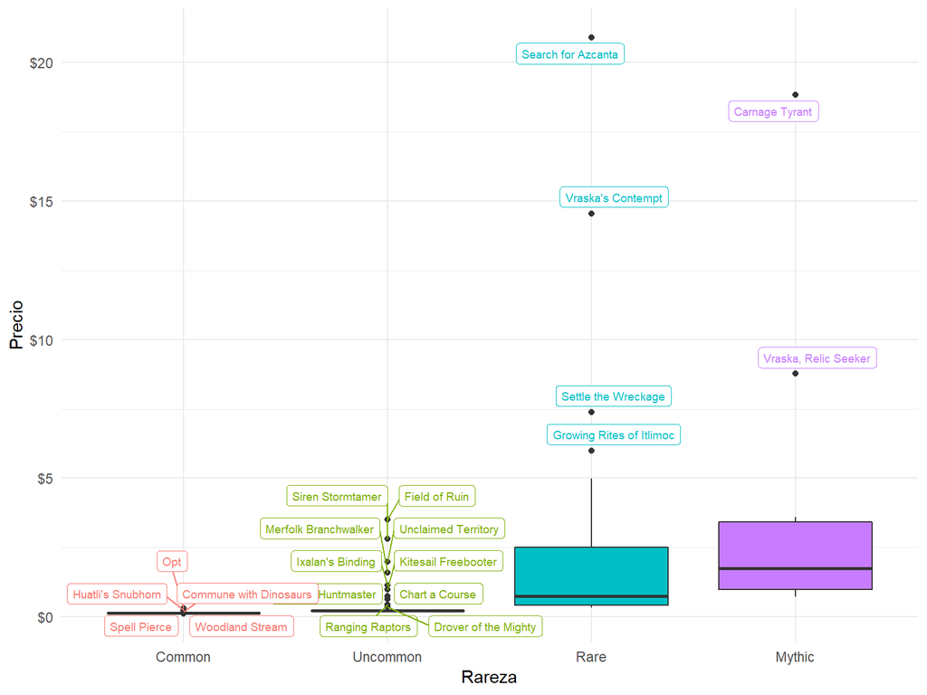

```
##
##
## $simulacion
## # A tibble: 397 x 3
##    Rareza   Valor Id_caja
##    <fct>    <dbl>   <int>
##  1 Common    4.46       1
##  2 Uncommon 37.3        1
##  3 Rare     35.3        1
##  4 Mythic   99.3        1
##  5 Common    6.21       2
##  6 Uncommon 33.4        2
##  7 Rare     29.4        2
##  8 Mythic   56.6        2
##  9 Common    5.42       3
## 10 Uncommon 33.0        3
## # ... with 387 more rows
##
## $valor
##   [1] 176.43 125.56  89.68  65.16  89.85  75.41 164.35 113.67  68.02 174.12
##  [11] 151.78 112.41 139.67  99.57 160.23 132.76  97.53 156.00 120.05 221.50
##  [21] 110.59  79.06 129.52 126.30 148.82 134.19  86.47  78.06 133.30  84.52
##  [31] 171.73 139.56 173.07  95.86 125.52 181.84  83.18 133.70  94.70  94.24
##  [41]  91.84  96.54 108.56 110.09 110.84  98.05  95.53 126.84  89.56 152.06
##  [51]  99.58  89.16  76.27 128.08  81.62  97.06  71.78 131.91 107.96  72.67
##  [61]  90.27 135.38  79.50  93.85 150.28  79.23 161.43 166.24 145.50  93.08
##  [71] 197.10  91.70 119.96  89.81 131.96 166.86  81.42 103.00  94.57 114.94
##  [81]  78.55 165.98 122.43 108.20 205.27 193.72  73.02  83.74 116.38  71.34
##  [91] 147.36  85.04  84.27  77.69  88.86  87.81 117.28  71.11 120.76 112.25
##
## $densidad
## $densidad$costo_pagado
## [1] 90
##
## $densidad$densidad
##
## Call:
##  density.default(x = valor_cajas)
##
## Data: valor_cajas (100 obs.);    Bandwidth 'bw' = 12.14
```

[output cut: 15 more lines]

```
##    <dbl>      <dbl> <chr>
##  1  28.7 0.00000938 Menor
##  2  29.2 0.0000106  Menor
##  3  29.6 0.0000120  Menor
##  4  30.1 0.0000135  Menor
##  5  30.5 0.0000152  Menor
##  6  31.0 0.0000171  Menor
##  7  31.4 0.0000192  Menor
##  8  31.9 0.0000215  Menor
##  9  32.3 0.0000241  Menor
## 10  32.8 0.0000270  Menor
## # ... with 502 more rows
##
##
## $inversion
```

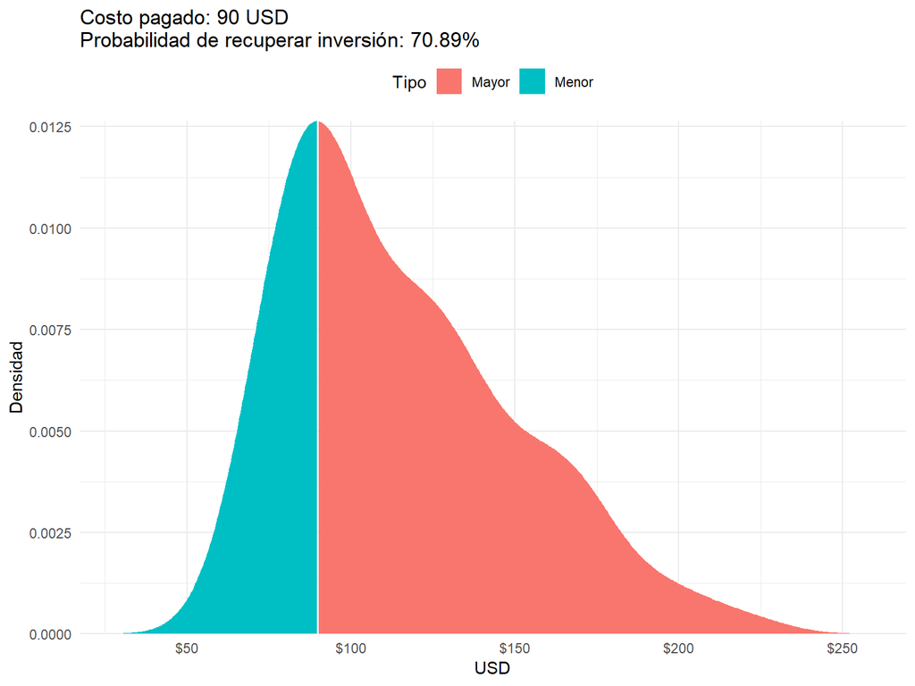

¡Vaya! Parece que es mejor invertir en “Dominaria” que en “Ixalan” su compramos cajas por 90 USD, pues tenemos una probabilididad un poco mayor de recuperar el dinero gastado.

# 10 Conclusiones

En este artículo revisamos las diferentes etapas de un pequeño proyecto de *Data Science* en el que hemos calculado la probabilidad de recuperar nuestra inversión al comprar cajas de sobres de Magic: the Gathering, a partir de la información de [MTG Goldfish](http://www.mtggoldfish.com)

Para esta tarea hemos usados los paquetes *xml2* y *rvest* para obtener y procesar información de un sitio web, así como la familia *tidyverse* con *ggrepel* y *scales* para analizar y visualizar resultados.

Creo que en términos generales hemos creado una herramienta que nos puede ayudar a tomar decisiones a la hora de comprar decisiones al gastar dinero en Magic, o al menos, entender mejor las tendencias financieras relacionadas con este juego de cartas coleccionable.

Desde luego, aún hay formas en las que podemos perfeccionar este proyecto, por ejemplo:

- Agregar a las funciones procedimientos para manejar errores y excepciones.
- Crear un panel interactivo con [Shiny](https://shiny.rstudio.com/).
- Mejorar la presentación visual de la información.
- Obtener los nombres de las cartas en varios idiomas.
- Convertir los precios de dólar norteamericano a moneda local (peso mexicano, en mi caso).

Pero algunas de estas cosas, pueden ser motivo de futuros proyectos.

Consultas, dudas, propuestas de temas, comentarios y correcciones son bienvenidas:

- jboscomendoza@gmail.com

El código y los datos usados en este documento se encuentran en Github:

- https://github.com/jboscomendoza/rpubs/tree/master/mtg_goldfish